### 1.1 Poisson glm

The data set `rabbit` contains data on a highly threatened rabbit species.

The variables in this data set are:

- `sights`: integer variable of camera trap sightings
- `distance`: distance to river (m)
- `degredation`: level of degradation (low, medium, very high)

**Question:** How does the degradation level of the site and the distance to the river influence the sightings of rabbits?

You can get the data with:

```r
rabbit <- readr::read_csv("https://raw.githubusercontent.com/selinaZitrone/intro-r-data-analysis/master/data/rabbit.csv")
```

**Tasks**

- Plot the data

```r
g <- ggplot(rabbit, aes(x=distance, y=sights, color = degradation))+
  geom_point()
```

- Fit a poisson glm (with or without interaction)

```r
rabbit_glm <- glm(sights ~ distance + degradation, data = rabbit, family = "poisson")
```

- Test the significant of the explanatory variables

```r
drop1(rabbit_glm, test = "Chisq")
```

```
## Single term deletions
##
## Model:
## sights ~ distance + degradation
##             Df Deviance    AIC    LRT  Pr(>Chi)
## <none>           639.27 1261.5
## distance     1  1195.56 1815.8 556.29 < 2.2e-16 ***
## degradation  2   764.22 1382.4 124.95 < 2.2e-16 ***
## ---
## Signif. codes:  0 '***' 0.001 '**' 0.01 '*' 0.05 '.' 0.1 ' ' 1
```

- Add the model to the plot

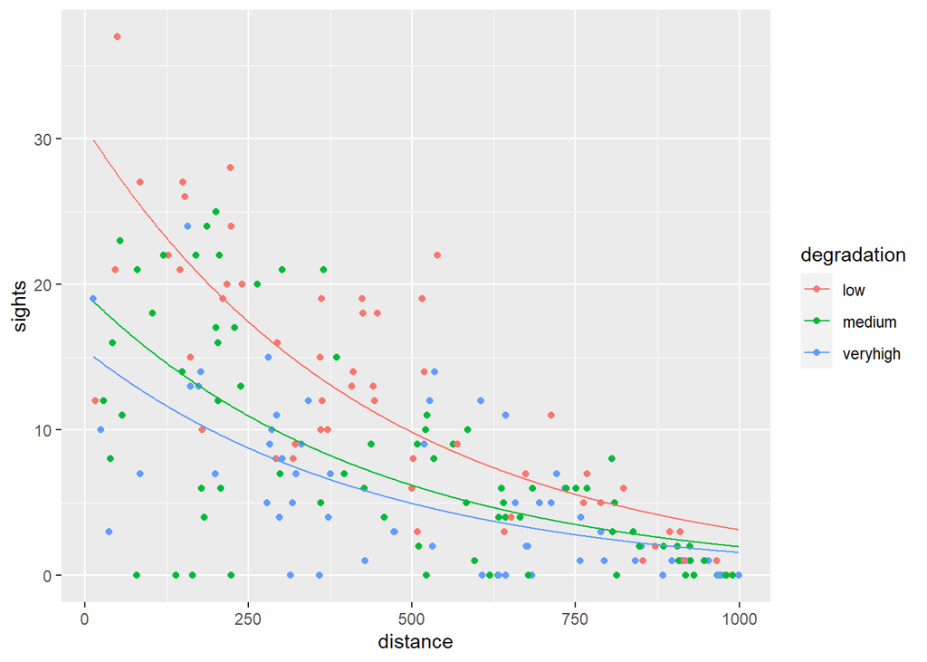

```r
pred_data <- expand_grid(
  distance = min(rabbit$distance):max(rabbit$distance),
  degradation = unique(rabbit$degradation)
)

pred_data$sights <- predict(rabbit_glm, newdata = pred_data, type = "response")

g +
  geom_line(data = pred_data)
```

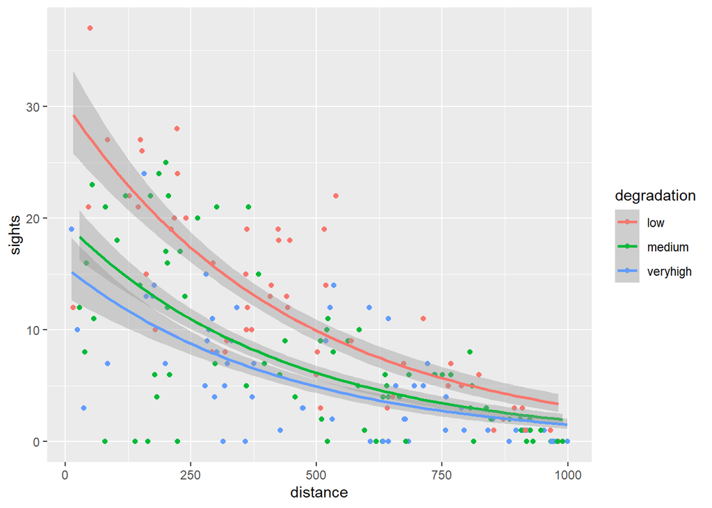

```r
g +
  geom_smooth(
    method = "glm",
    method.args = list(
      family = "poisson"
    )
  )
```

#### Extra

- Make the plot look nice

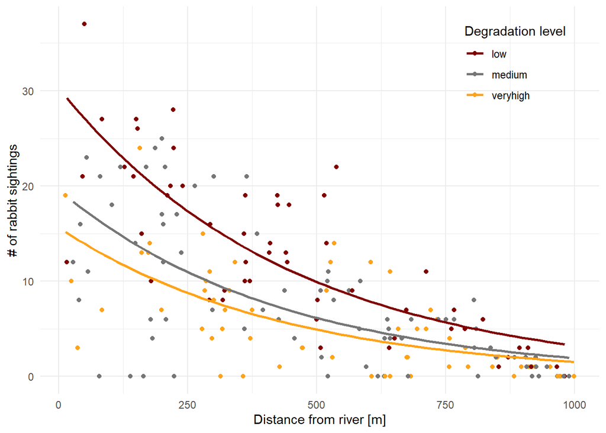

```r
g +
  geom_smooth(
    se = FALSE,
    method = "glm",
    method.args = list(
      family = "poisson"
    )
  ) +
  ggsci::scale_color_uchicago() +
  theme_minimal() +
  labs(y = "# of rabbit sightings", x = "Distance from river [m]", color = "Degradation level") +
  theme(legend.position = c(0.85, 0.85))
```

### 1.2 Binary glm

The data set is about the occurrence of woodpeckers at forest sites depending on the amount of deadwood and the dominant tree species.

The variables in the data set are:

- `bird_pres`: binary response variable (presence/absence of the bird at the site)
- `species`: dominant tree species at the site
- `deadwood`: amount of deadwood at the site

**Question:** How does the the amount of deadwood and the dominant tree species influence the probability of woodpecker presence?

You can get the data with:

```r
bird <- read_tsv("https://raw.githubusercontent.com/selinaZitrone/intro-r-data-analysis/master/data/bird.csv")
```

- Plot the data

```r
g2 <-ggplot(bird, aes(x=deadwood, y= bird_pres, color =species))+
  geom_point()
```

- Fit a binary glm (`family = "binomial"`)

```r
bird_glm <- glm(bird_pres ~ deadwood + species, data = bird, family = "binomial")
```

- Test the significance of the predictors

```r
drop1(bird_glm, test = "Chisq")
```

```
## Single term deletions
##
## Model:
## bird_pres ~ deadwood + species
##          Df Deviance    AIC     LRT Pr(>Chi)
## <none>        129.75 137.75
## deadwood  1   271.88 277.88 142.124  < 2e-16 ***
## species   2   137.71 141.71   7.953  0.01875 *
## ---
## Signif. codes:  0 '***' 0.001 '**' 0.01 '*' 0.05 '.' 0.1 ' ' 1
```

- Plot the data and add model predictions

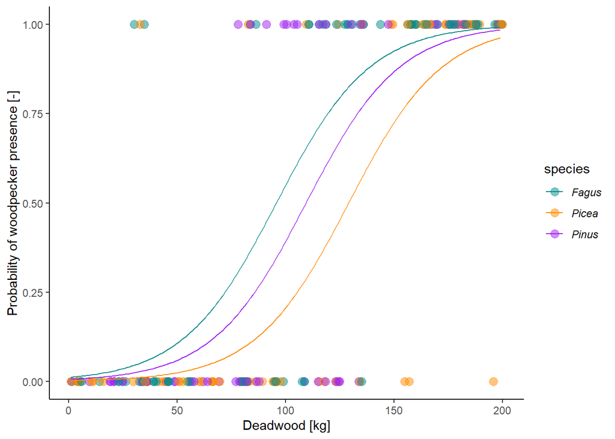

```r
pred_data <- expand_grid(
  deadwood = min(bird$deadwood):max(bird$deadwood),
  species = unique(bird$species)
)
pred_data$bird_pres <- predict(bird_glm, newdata = pred_data, type = "response")

ggplot(bird, aes(x=deadwood, y= bird_pres, color =species))+
  geom_point(alpha=0.5, size = 3)+
  geom_line(data = pred_data)+
  theme_classic()+
  scale_color_manual(values = c("cyan4", "darkorange", "purple")) +
  labs(y="Probability of woodpecker presence [-]", x = "Deadwood [kg]") +
  theme(
    legend.text = element_text(face = "italic")
  )
```

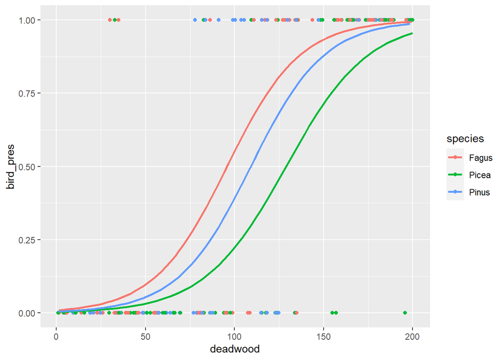

```r
# or with geom smooth
# careful: this is plotting the model with interaction
g2 +
  geom_smooth(method = "glm",se=FALSE,
              method.args = list(
                family = "binomial"
              ))
```